# Mapping Maps to other Maps

Ernesto Carrella

February 26, 2016

## Mapping

The two components of our inhouse biological model are the 5 species characteristics and their geographical locations. I’ve been working on both in parallel however there are some geographical questions I’d like to present looking for feedback.

What we have is a bathymetry file for california:

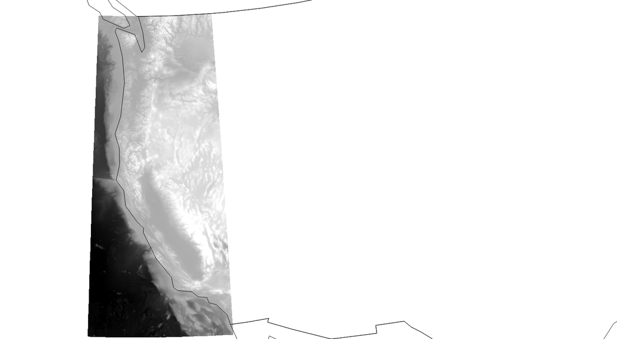

And then Steve Saul generated raster abundance files for the species we are studying:

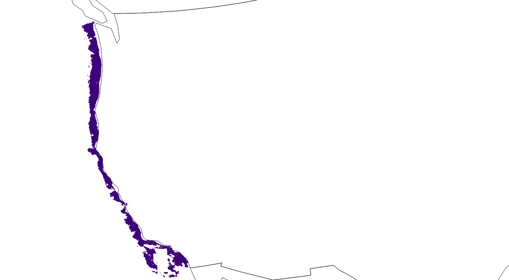

I’ve been hard at work to input this data into the model.

In general the agent-based framework we are using doesn’t support GIS data. What it does is to read already projected observations and treat the projected map as a cartesian space.  
After reprojecting everything over UTM 10N I can merge all the data we have in our nice grids (of variable size) and input them in the model:

[video not shown]

While this looks fine, I am not sure how accurate this approach is. My main fear is that the real area portrayed by each cell is slightly different as we pick up projection distortions.  
How should we deal with it? Should we weigh biomass distribution and catchability values by the size of the cell? Could be very tricky.  
I could translate everything into latitude and longitude but would that actually solve anything?  
I am very weak on this point and any suggestion is more than welcome.